# Bienestar subjetivo y desigualdades sociales (ESS6)

2026-08-24

## Introducción

- Proyecto basado en la European Social Survey (ESS6).
- Se analizan distintas dimensiones del bienestar subjetivo.
- Se estudian las desigualdades sociales asociadas al bienestar.
- El análisis permitió identificar los principales factores explicativos y diseñar un dashboard interactivo para su exploración.

## Objetivos

### Objetivo general

Analizar cómo distintos factores sociales, educativos y económicos se relacionan con el bienestar subjetivo en Europa.

### Objetivos específicos

- Identificar los principales determinantes del bienestar.
- Comparar perfiles de bienestar entre grupos sociales.
- Seleccionar variables relevantes para el dashboard.
- Comunicar resultados mediante herramientas reproducibles.

## Descripción de la muestra

- Base de datos: European Social Survey (ESS6).
- Participantes: **54.673**
- Países: 29.
- Edad media: **48.3** años.
- Felicidad media: **7.11** puntos sobre 10.

### Indicadores analizados

- Felicidad
- Salud percibida
- Dirección vital
- Libertad para decidir
- Relaciones sociales
- Apoyo íntimo
- Tiempo para uno mismo

## Distribución de felicidad

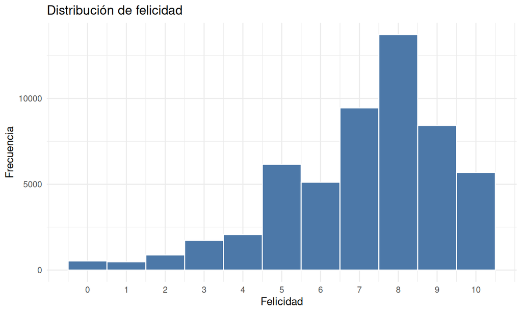

## Principal hallazgo: ingresos y bienestar

Los ingresos constituyen el principal factor asociado al bienestar subjetivo. ``

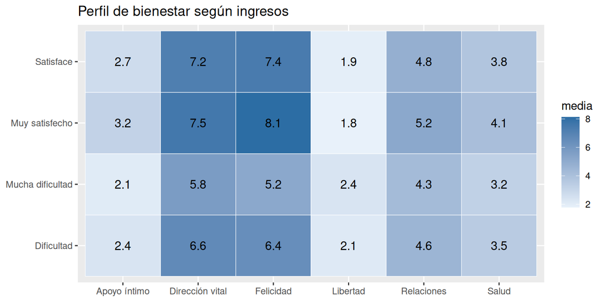

## Hallazgo secundario: educación y bienestar

Los niveles educativos más elevados presentan perfiles de bienestar más favorables.

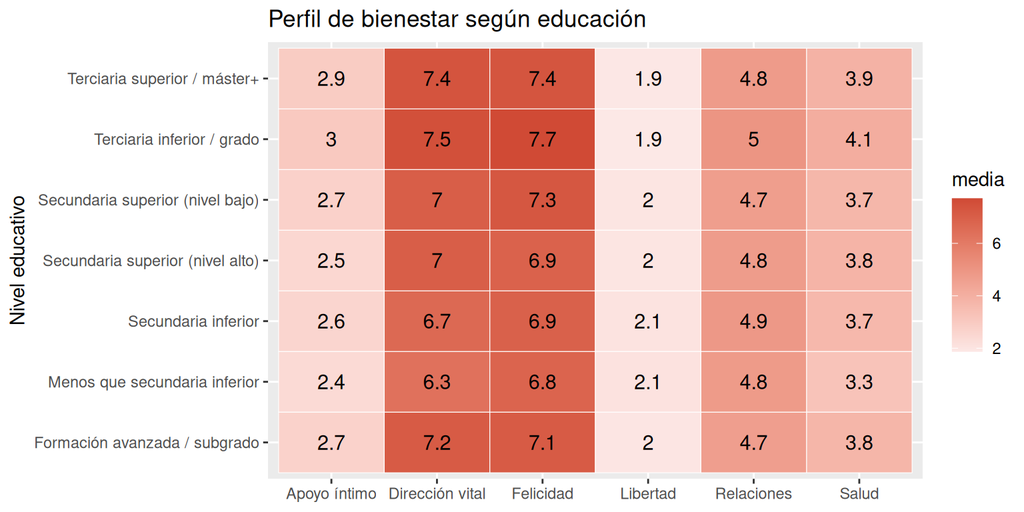

## Dashboard y conclusiones

### Diseño del dashboard

Los resultados del análisis exploratorio mostraron que:

- Los ingresos son el principal factor asociado al bienestar.
- La educación constituye un segundo eje explicativo relevante.
- Sexo, edad, hijos, pareja y divorcio aportan capacidad de segmentación.

Por ello, el dashboard se construyó utilizando ingresos y educación como variables principales y el resto como filtros interactivos.

La estructura del dashboard reproduce directamente los resultados obtenidos durante el análisis exploratorio del Reto 1, permitiendo explorar de forma interactiva los principales patrones identificados en los datos.